# Análisis de Extorsiones en Guayaquil

Factores de Asociación y Tendencia Temporal (2021-2024).

Helen Analía Ruíz Jácome, Delgado Zambrano Diego, Rojas Dueñas Valeria, Sánchez Zambrano Arelys, Teran Arroyo Emily

Febrero 2026

# 1. Problema

## 1.1. Planteamiento del Problema

Durante los últimos años nuestro país ha sufrido un agrietamiento progrsivo en lo que compete a la seguridad ciudadana, siendo Guayaquil una de las ciudades con el mayor índice de crímenes violentos. Entre estos delitos se encuentra el de extorsión, coloquialmente llamado vacuna, el cual ha pasado a un primer plano y desafortunadamente a un primer plano en distintas ubicaciones de la Zona 8 dentro de la cuál se ubica Guayaquil.

El período de años comprendido entre 2021 y 2024 marcó un punto de partida a un desafortunado día a día con altos índices de criminalidad y en específico de delitos extorsivos, los cuales varían en su modus operandi, incrementando los niveles de violencia dentro de nuestra ciudad.

Sin embargo, el problema central no es solo el aumento de casos, sino la falta de caracterización estadística. Actualmente, se desconoce si la extorsión es homogénea en toda la ciudad o si existen distritos identificables como “puntos calientes” para modalidades específicas. La ausencia de un análisis inferencial impide predecir si el alza responde a una tendencia aleatoria o a un patrón de crecimiento sistemático, limitando la capacidad de respuesta basada en evidencia.

## 1.2. Preguntas de Investigación e Hipótesis

### Preguntas de Investigación:

- ¿La extorsión es similar en toda la ciudad o existen distritos identificables como puntos calientes para modalidades específicas?
- ¿El alza en el índice de extorsiones responde a una tendencia aleatoria o sigue un patrón de crecimiento predecible?

### Hipótesis Cualitativa:

El crecimiento gradual en la cantidad de delitos extorsivos y la “innovación” de sus modalidades provocan un impacto que trasciende la pérdida económica, generando un cambio en la forma de vida de los afectados, el cierre de microempresas y la normalización de la violencia como mecanismo de regulación ilegal en las zonas más recurrentes.

# Objetivos

## Objetivo General

Analizar los factores de asociación entre los datos geográficos y la tendencia temporal de los delitos extorsivos dentro de la ciudad de Guayaquil durante el período 2021-2024 utilizando la estadística inferencial no paramétrica para identificar patrones en los delitos.

## Objetivos Específicos

1. Identificar el problema mediante la caracterización de los perfiles delictivos de las extorsiones dentro de la zona 8 utilizando tablas y gráficos para describir la frecuencia de las modalidades de extorsión, la distribución geográfica y niveles de violencia explícita.
2. Determinar si existe relación significativa entre la ubicación geográfica y el tipo de amenaza usando la prueba de independencia Ji- Cuadrado $(\chi^2)$
3. Elaborar una solución analítica evaluando la tendencia de la incidencia en los delitos de extorsión durante la serie de tiempo mensual dentro del período 2021 - 2024, usando el coeficiente de correlación de Spearman ($\rho$) para comprobar el incremento gradual en los casos de extorsiones.

# 2. Fundamento Teórico

## 2.1 Marco Teórico

Para la fundamentación de este estudio, se revisó la literatura existente articulando la criminología ambiental y la economía del crimen. Se analizaron tres posturas teóricas principales para explicar el fenómeno en Guayaquil (2021-2024):

### Teoría de la Elección Racional y Economía del Crimen

Se partió de la perspectiva del criminal como un agente racional. Según Jaitman (2022), la extorsión proliferaba cuando la “rentabilidad” del delito superaba el riesgo de sanción. En el contexto latinoamericano, InSight Crime (2022) estableció que la impunidad y la baja capacidad estatal actuaban como incentivos perversos, permitiendo que la extorsión dejara de ser un evento aleatorio para convertirse en una actividad económica planificada.

### Teoría de las Actividades Rutinarias y el Entorno Urbano

Esta teoría sostenía que el delito ocurría por la convergencia de un agresor, un objetivo y la ausencia de vigilancia. Investigaciones en puertos como Guayaquil sugirieron que la densidad poblacional creaba “zonas calientes”. Alvarado y Mendieta (2023) argumentaron que la extorsión había mutado a un mecanismo de control territorial, donde la “ausencia del guardián” representaba la erosión del tejido social en ciertos distritos.

### Teoría de la Gobernanza Criminal

Para explicar el crecimiento exponencial, se recurrió a la teoría de la gobernanza criminal. Sampó (2023) destacó que la fragmentación de bandas en Sudamérica generó una competencia violenta por la extracción de rentas. En este escenario, los grupos organizados asumieron funciones paraestatales, cobrando “vacunas” a cambio de una seguridad ficticia, transformando la dinámica delictiva en una disputa por soberanía local.

## 2.2 Marco Conceptual

Para la operacionalización de las variables estadísticas, se definieron los siguientes constructos basados en la revisión bibliográfica:

### Extorsión Sistemática (“Vacuna”)

Se definió como el cobro periódico y coercitivo a cambio de protección. El Observatorio Ecuatoriano de Crimen Organizado [OECO] (2023) reportó que esta tipología creció un 400% en el periodo de estudio, diferenciándose de la extorsión simple por su carácter recurrente.

### Factores de Asociación (Covariables)

Se entendieron como las variables espaciales correlacionadas con la incidencia delictiva. Rivera (2024) señaló que la presencia territorial hegemónica de ciertos Grupos Delictivos Organizados (GDOs) en sectores censales específicos era un factor determinante para la virulencia de la extorsión, variable que en este estudio se analizó a través de la segregación por Distritos.

### Tendencia Temporal y Estacionalidad

Se refirió al comportamiento de la serie de datos (2021-2024). Carrión (2024) indicó que la ruptura estructural de las series de tiempo delictivas en Ecuador coincidió con los estados de excepción y la declaratoria de conflicto armado, sugiriendo un crecimiento tendencial más que estacional.

### Cifra Negra

Concepto crítico que representó los delitos no denunciados. La UNODC (2023) estimó que la subnotificación en casos de extorsión podía superar el 80% debido al temor a represalias, lo cual se consideró como un sesgo inherente al análisis de fuentes oficiales.

## 2.3 Marco Legal

La investigación se encaminó en la normativa vigente del Ecuador y sus reformas ante la crisis de seguridad:

### Constitución de la República (2008):

Se consideraron los arts. 3 y 66 sobre el derecho a la seguridad integral.

### Código Orgánico Integral Penal (COIP):

Se analizó el Art. 185 (Extorsión), destacando las reformas de 2022-2023 que agravaron las penas para delitos cometidos por delincuencia organizada.

### Decretos Ejecutivos:

Se tomó en cuenta el Decreto Ejecutivo No. 111 (2024), citado por Ecuador (2024), el cual reclasificó a las bandas extorsionadoras como “objetivos militares”.

# 3. Metodología

## 3.1 Tipo de investigación

El presente estudio se concentra en un enfoque inferencial para el cual es necesario realizar previamente un análisis exploratorio utilizando estadística descriptiva. Se utiliza un diseño no experimental y longitudinal, puesto que se analizan datos históricos de denuncias por delitos extorsivos recopiladas durante un periodo de cuatro años (2021-2024) sin manipulación deliberada de variables. Dado que los datos no siguen una distribución normal, se plantearon las siguientes hipótesis estadísticas no paramétricas:

### Para la Asociación Espacial (Chi-Cuadrado):

$H_0$: El nivel de peligrosidad es independiente del Distrito Administrativo.

$H_1$: Existe una asociación significativa entre el Distrito y el nivel de peligrosidad.

### Para la Tendencia Temporal (Spearman):

$H_0$: La frecuencia mensual de extorsiones no tiene tendencia significativa (es aleatoria).

$H_1$: Existe una correlación positiva significativa ($\rho > 0$) entre el tiempo transcurrido y la cantidad de denuncias.

## 3.2 Definición y operacionalización de variables (Variables X – Y)

Para las pruebas de hipótesis, se definieron las siguientes variables:

### Prueba 1 (Asociación Espacial):

Variable Independiente ($X_1$): Distrito (Cualitativa Nominal).

Variable Dependiente ($Y_1$): Amenaza de Muerte / Peligrosidad (Cualitativa Binaria/Ordinal).

### Prueba 2 (Tendencia Temporal):

Variable Independiente ($X_2$): Tiempo (Meses transcurridos - Cuantitativa Discreta).

Variable Dependiente ($Y_2$): Frecuencia de casos (Cuantitativa Discreta).

## 3.3 Población y muestra

Población: La población objetivo teórica comprende la totalidad de víctimas de extorsión en la Zona 8 durante el periodo 2021-2024.

Muestra: Se empleó un muestreo no probabilístico por conveniencia. La unidad de análisis está constituida por 3.629 registros correspondientes a las denuncias efectivamente ingresadas en el sistema y disponibles para el estudio, a los cuales se le aplicó una limpieza de valores faltantes para el correcto análisis debido a las limitaciones en cuanto a contenido de imputación de datos, teniendo como resultado en la muestra final un total de 2986 registros.

Justificación: Debido a la existencia de cifra negra que son los delitos no denunciados, esta base de datos correspondiente a las denuncias al ECU911 por los delitos de extorsión entre los años 2021 y 2024, utilizó el método de muestreo por conveniencia ya que tomó todos los datos disponibles y no se clasificaban cual llamada contestar y cual no sino que todo al que llamaba se le atendió.

## 3.4 Métodos

### Análisis Descriptivo y Exploratorio

Se aplicaron medidas de frecuencia y gráficos de visualización (series temporales, mapas de calor y diagramas de barras) para caracterizar el comportamiento de las variables.

### Inferencia Estadística

Debido a la naturaleza no paramétrica de los datos delictivos (distribuciones no normales), se seleccionaron las siguientes pruebas de significancia con un nivel de confianza del 95% ($\alpha = 0.05$):

Prueba Chi-cuadrado de Pearson ($\chi^2$):

Para determinar la independencia entre variables cualitativas ($X_1$ vs $Y_1$).

Coeficiente de Correlación de Spearman ($\rho$):

Para evaluar la fuerza y dirección de la tendencia monótona entre el tiempo y la incidencia ($X_2$ vs $Y_2$).

A continuación se detallan las variables seleccionadas del conjunto de datos para el análisis estadístico:

| Variable | Tipo de Variable | Descripción Operativa |
| --- | --- | --- |
| **Año / Mes** | Cuantitativa Discreta | Unidades temporales del evento. Utilizadas para la agrupación mensual y el análisis de series de tiempo (tendencias). |
| **Fecha.Hora** | Cuantitativa Continua | Marca temporal exacta del registro. Permite la extracción de patrones horarios y estacionalidad semanal. |
| **Distrito** | Cualitativa Nominal | División administrativa policial donde ocurre el hecho (Zona 8). Variable principal para el análisis de segregación espacial. |
| **Latitud / Longitud** | Cuantitativa Continua | Coordenadas geográficas. Utilizadas para la georreferenciación y creación de mapas de densidad. |
| **Medio** | Cualitativa Nominal | Canal o vía utilizada para ejecutar la extorsión (Ej: “WhatsApp”, “Panfleto”). Indicador de innovación delictiva. |
| **AmenazaMuerte** | Cualitativa Binaria | Variable dicotómica (Sí/No) que indica la presencia de amenazas explícitas contra la vida. Proxy de violencia extrema. |
| **Peligrosidad** | Cualitativa Ordinal | Clasificación jerárquica del riesgo asociado al evento (Ej: Baja, Media, Alta). |
| **Victima** | Cualitativa Nominal | Categorización del afectado (Ej: “Dueño de local”, “Transeúnte”). Permite inferir el impacto en el sector comercial (“Microempresarios”). |
| **Valor** | Cuantitativa Continua | Monto económico exigido en la extorsión. Representa la cuantificación del impacto patrimonial directo. |

# 4. Resultados

## 4.1 Análisis Exploratorio

Antes de proceder con las pruebas de inferencia, se presenta un análisis descriptivo para comprender la estructura de los datos.

```r
datos_eda <- read_excel("Datos_Extorsion.xlsx") %>%
  clean_names() %>%
  mutate(
    fecha_hora_obj = ymd_hms(fecha_hora),
    hora = hour(fecha_hora_obj),
    dia_semana = wday(fecha_hora_obj, label = TRUE, abbr = FALSE, week_start = 1),
    amenaza_limpia = case_when(
      str_detect(as.character(amenaza_muerte), "^1") ~ "SI",
      amenaza_muerte == "Amenaza de muerte: 1" ~ "SI",
      amenaza_muerte == "Recibió amenaza de muerte: 1" ~ "SI",
      str_detect(as.character(amenaza_muerte), "^0") ~ "NO",
      str_detect(as.character(amenaza_muerte), "^No hay amenaza") ~ "NO",
      str_detect(as.character(amenaza_muerte), "^No se menciona") ~ "NO",
      str_detect(as.character(amenaza_muerte), "Amenaza de muerte: 0") ~ "NO",
      tolower(amenaza_muerte) %in% c("no", "ninguna", "ninguno") ~ "NO",
      TRUE ~ NA_character_
    )
  ) %>%
  filter(!is.na(amenaza_limpia))

datos_eda <- drop_na(datos_eda)
#Eliminamos las  filas con datos faltantes y limpiamos las variables a utilizar
```

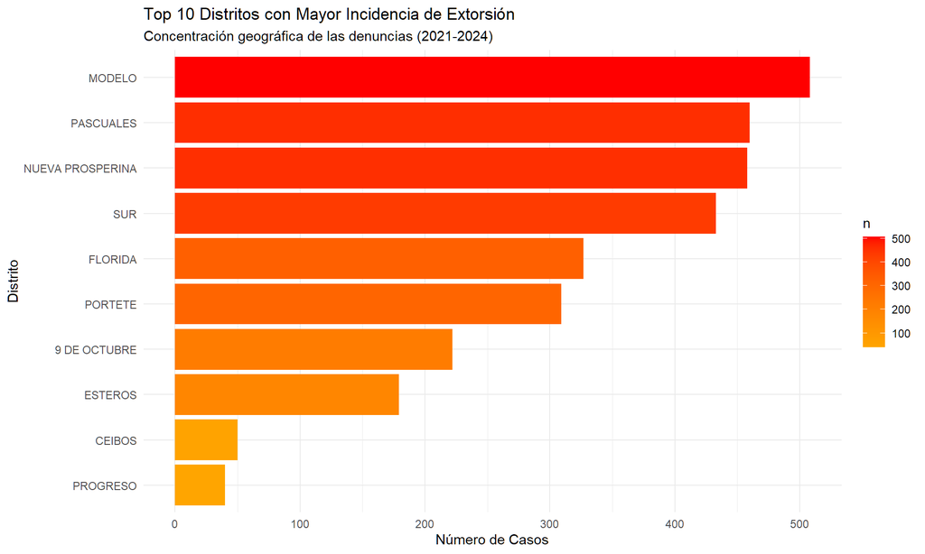

```r
# GRÁFICO 1: Top 10 Distritos más peligrosos
grafico_distritos <- datos_eda %>%
  count(distrito, sort = TRUE) %>%
  top_n(10, n) %>%
  ggplot(aes(x = reorder(distrito, n), y = n, fill = n)) +
  geom_col() +
  coord_flip() +
  labs(
    title = "Top 10 Distritos con Mayor Incidencia de Extorsión",
    subtitle = "Concentración geográfica de las denuncias (2021-2024)",
    x = "Distrito",
    y = "Número de Casos"
  ) +
  theme_minimal() +
  scale_fill_gradient(low = "orange", high = "red")

print(grafico_distritos)
```

Aquí podemos observar que el distrito con mayor cantidad de extorsiones durante el período de estudio fue el Modelo, conocido como Distrito 5 Centro que está conformado por los circuitos Urdesa, Kennedy, Atarazana, Alborada, Sauces y Guayacanes

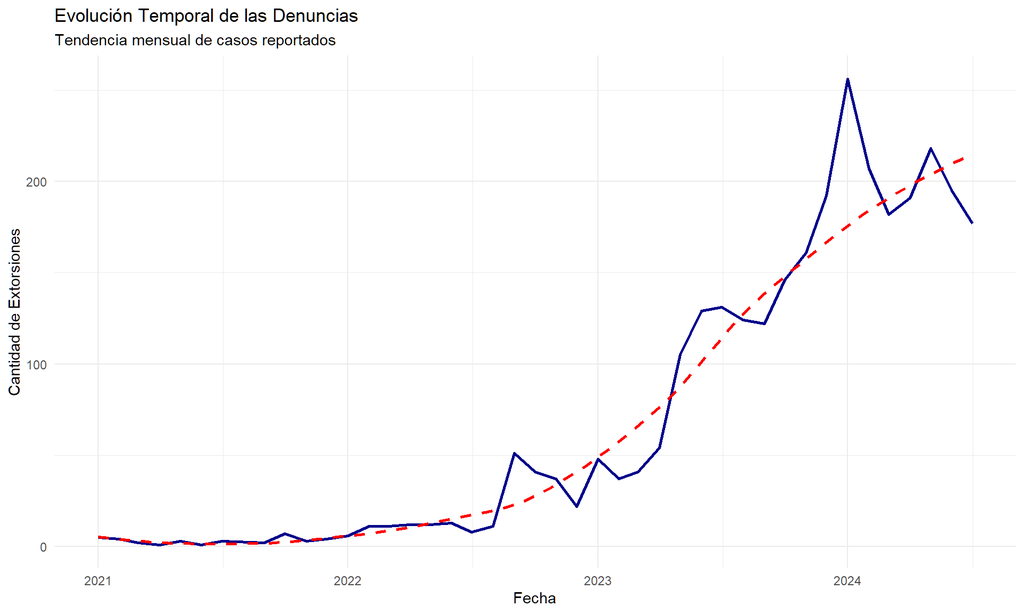

```r
# GRÁFICO 2: Evolución Mensual (Línea de Tiempo)
grafico_tiempo <- datos_eda %>% drop_na() %>%
  mutate(fecha_mes = floor_date(fecha_hora_obj, "month")) %>%
  count(fecha_mes) %>%
  ggplot(aes(x = fecha_mes, y = n)) +
  geom_line(color = "darkblue", size = 1) +
  geom_smooth(method = "loess", color = "red", linetype = "dashed", se = FALSE) +
  labs(
    title = "Evolución Temporal de las Denuncias",
    subtitle = "Tendencia mensual de casos reportados",
    x = "Fecha",
    y = "Cantidad de Extorsiones"
  ) +
  theme_minimal()

print(grafico_tiempo)
```

Se observa un incremento sustancial en la cantidad de extorsiones desde 2023 en adelante.

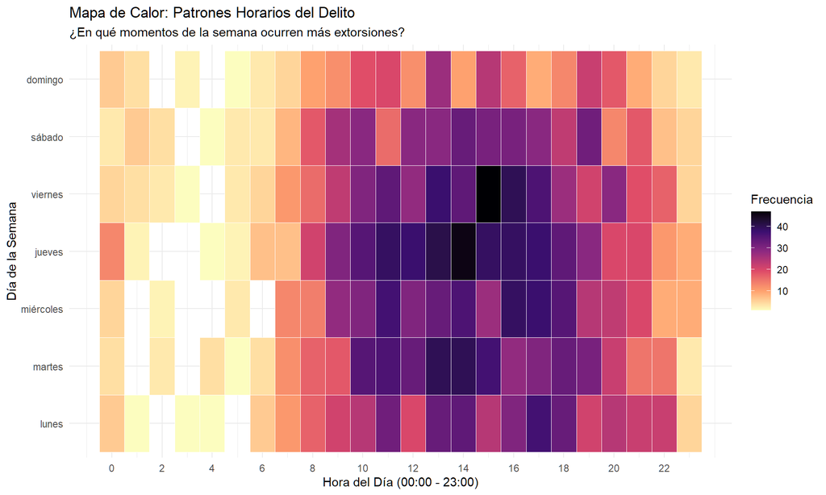

```r
# GRÁFICO 3: Mapa de Calor (Día vs Hora)
grafico_heatmap <- datos_eda %>% drop_na() %>%
  count(dia_semana, hora) %>%
  ggplot(aes(x = hora, y = dia_semana, fill = n)) +
  geom_tile(color = "white") +
  scale_fill_viridis_c(option = "magma", direction = -1) +
  labs(
    title = "Mapa de Calor: Patrones Horarios del Delito",
    subtitle = "¿En qué momentos de la semana ocurren más extorsiones?",
    x = "Hora del Día (00:00 - 23:00)",
    y = "Día de la Semana",
    fill = "Frecuencia"
  ) +
  theme_minimal() +
  scale_x_continuous(breaks = seq(0, 23, 2))

print(grafico_heatmap)
```

Aquí podemos observar que la mayor ocurrencia de extorsiones se concentra entre Jueves y viernes, entre el mediodía y las cuatro de la tarde.

```r
# Filtrar datos válidos
datos_mapa <- datos_eda %>%
  filter(!is.na(latitud) & !is.na(longitud)) %>%
  mutate(
    lat = as.numeric(latitud),
    lng = as.numeric(longitud)
  )

datos_mapa %>%
  leaflet() %>%
  addProviderTiles(providers$CartoDB.Positron) %>%
  setView(lng = -79.90, lat = -2.17, zoom = 11) %>% #Coordenadas de guayaquil
  addHeatmap(
    lng = ~lng,
    lat = ~lat,
    intensity = ~1,
    blur = 20,
    max = 0.05,
    radius = 15
  ) %>%
  addLegend(
    position = "bottomright",
    title = "Densidad de Extorsiones",
    colors = c("blue", "lime", "yellow", "red"),
    labels = c("Baja", "Media", "Alta", "Crítica")
  )
```

[interactive chart not shown]

En este mapa de calor se puede ver que la mayoría de extorsiones ocurren dentro de circuitos urbanos de la ciudad, la mayor concentración a simple vista parecen ser los distritos del norte y del sur de la ciudad, esto podría indicar una poca variabilidad en la distancia que separa a cada delito extorsivo dentro de estos distritos.

## 4.2 Pruebas de Hipótesis

### Primera Prueba

Con el objetivo de verificar si la violencia del delito extorsivo ocurre de acuerdo al sector, se realizó una prueba Ji-Cuadrado, para esto planteamos la siguiente Hipótesis Nula:

$H_0:$ El nivel de peligrosidad es independiente del Distrito Administrativo. (el nivel de violencia es igual en todos los distritos)

Y su Hipótesis Alternativa:

$H_1:$ Existe una asociación significativa entre el Distrito Administrativo y el nivel de peligrosidad. (al menos un distrito tiene diferente nivel de violencia)

- Variable Independiente: Distrito (nominal)
- Variable Dependiente: AmenazaMuerte (Binaria: Si/No)

```r
tabla_contingencia <- table(datos_eda$distrito, datos_eda$amenaza_limpia)

prueba_chi <- chisq.test(tabla_contingencia)

resumen_chi <- data.frame(
  Hipótesis = "Independencia (Distrito vs. Amenaza)",
  Estadístico_Chi = round(prueba_chi$statistic, 2),
  Grados_Libertad = as.numeric(prueba_chi$parameter),
  P_Valor = format.pval(prueba_chi$p.value, digits = 6, eps = 0.001),
  Decisión_Estadística = ifelse(prueba_chi$p.value < 0.05,
                                "RECHAZAR H0 (Existe Asociación)",
                                "NO RECHAZAR H0")
)

resumen_chi %>%
  kable(caption = "Tabla 1: Resultado de la Prueba Chi-Cuadrado") %>%
  kable_styling(bootstrap_options = c("striped", "hover", "condensed"), full_width = F)
```

Tabla 1: Resultado de la Prueba Chi-Cuadrado

|  | Hipótesis | Estadístico_Chi | Grados_Libertad | P_Valor | Decisión_Estadística |
| --- | --- | --- | --- | --- | --- |
| X-squared | Independencia (Distrito vs. Amenaza) | 49.82 | 9 | < 0.001 | RECHAZAR H0 (Existe Asociación) |

Puesto que el valor p de nuestra prueba de hipótesis es menor al nivel de significancia $(0.05)$ rechazamos la hipótesis nula, esto quiere decir que con un $95\%$ de confianza existe evidencia suficiente para decir que hay una diferencia significativa de nivel de peligrosidad entre distritos, es decir que hay una relación entre el distrito y la cantidad de amenazas de muerte en las extorsiones.

### Segunda Prueba

Para demostrar estadísticamente que existe crecimiento en los delitos extorsivos planteamos el siguiente contraste usando una prueba no paramétrica, específicamente la Correlación de Spearman:

$H_0:$ La frecuencia de delitos de extorsión por mes, no tienen una tendencia monótona significativa (existe aleatoriedad o es constante)

Y su Hipótesis Alternativa:

$H_1:$ Existe una correlación positiva significativa ($\rho \gt 0$) entre el tiempo transcurrido y la cantidad de denuncias.

- Variables: Tiempo (Año-Mes) vs. Frecuencia de casos.

```r
datos_tendencia <- datos_eda %>%
  mutate(mes_anio = floor_date(fecha_hora_obj, "month")) %>%
  group_by(mes_anio) %>%
  summarise(total_casos = n()) %>%
  arrange(mes_anio) %>%
  mutate(tiempo_index = row_number())

correlacion <- cor.test(datos_tendencia$tiempo_index,
                        datos_tendencia$total_casos,
                        method = "spearman")
resumen_spearman <- data.frame(
  Hipótesis = "Tendencia Monótona (Tiempo vs. Casos)",
  Coeficiente_Rho = round(correlacion$estimate, 3),
  P_Valor = format.pval(correlacion$p.value, digits = 4, eps = 0.001),
  Decisión_Estadística = ifelse(correlacion$p.value < 0.05,
                                "RECHAZAR H0 (Existe Tendencia)",
                                "NO RECHAZAR H0")
)
resumen_spearman %>%
  kable(caption = "Tabla 2: Resultado de la Correlación de Spearman") %>%
  kable_styling(bootstrap_options = c("striped", "hover", "condensed"), full_width = F)
```

Tabla 2: Resultado de la Correlación de Spearman

|  | Hipótesis | Coeficiente_Rho | P_Valor | Decisión_Estadística |
| --- | --- | --- | --- | --- |
| rho | Tendencia Monótona (Tiempo vs. Casos) | 0.962 | < 0.001 | RECHAZAR H0 (Existe Tendencia) |

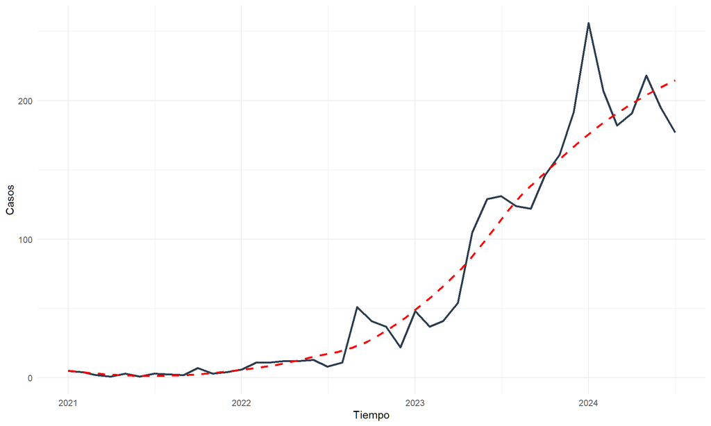

```r
ggplot(datos_tendencia, aes(x = mes_anio, y = total_casos)) +
  geom_line(color = "#2c3e50", size = 1) +
  geom_smooth(method = "loess", color = "red", linetype = "dashed", se = F) +
  labs(x = "Tiempo", y = "Casos") +
  theme_minimal()
```

Dado que el valor p de nuestra prueba de hipótesis resultó menor al nivel de significancia $(0.05)$ rechazamos la hipótesis nula, esto quiere decir que con un $95\%$ de confianza existe evidencia suficiente para decir que hay una diferencia significativa en la cantidad de extorsiones por cada período de tiempo, aquí podemos reforzar lo observado en el gráfico de crecimiento de casos a lo largo del tiempo donde se presenta una alza sustancial alrededor del año $2023$.

# Conclusiones

En cumplimiento con los objetivos planteados al inicio de esta investigación, y tras el análisis estadístico de los datos, se concluye lo siguiente:

## Asociación Espacial de la Violencia

Se determinó estadísticamente, mediante la Prueba de Independencia Chi-Cuadrado ($\chi^2$), que existe una asociación significativa ($p < 0.05$) entre el Distrito Administrativo y el Nivel de Peligrosidad (Amenaza de Muerte). Esto permite concluir que la violencia letal no es aleatoria; existen “zonas rojas” donde la probabilidad de recibir una amenaza contra la vida es significativamente mayor que en otras áreas, validando la existencia de territorios con gobernanza criminal diferenciada.

## Tendencia Temporal

Se evaluó el comportamiento histórico del delito mediante el Coeficiente de Correlación de Spearman ($\rho$), obteniendo un resultado positivo y significativo. Esto confirma que el incremento de las denuncias durante el periodo 2021-2024 obedece a una tendencia monótona creciente (estructural) y no a fluctuaciones estacionales o eventos aislados. La extorsión ha mostrado una escalada sistemática que se correlaciona con los periodos de inestabilidad política y estados de excepción.

## Propuesta de Solución

# Referencias Bibliográficas

Alvarado, N., & Mendieta, L. (2023). Geografía del miedo: Análisis espacial de la violencia criminal en el litoral ecuatoriano. Revista Latinoamericana de Estudios de Seguridad, 15(2), 45-68.

Carrión, F. (2024). El giro punitivo y la crisis de seguridad en Ecuador: Delincuencia común vs. Crimen Organizado. FLACSO Ecuador, Ediciones La Flauta Mágica.

Ecuador, Presidencia de la República. (2024). Decreto Ejecutivo No. 111: Reconocimiento del conflicto armado interno. Registro Oficial.

InSight Crime. (2022). Balance de InSight Crime sobre los homicidios y la extorsión en América Latina 2022. Recuperado de https://es.insightcrime.org.

Jaitman, L. (2022). Crime and Violence in Latin America and the Caribbean: The Evolving Landscape. Annual Review of Criminology, 5, 259-282.

Observatorio Ecuatoriano de Crimen Organizado (OECO). (2023). Informe semestral: La evolución de la extorsión en Ecuador. Pan American Development Foundation.

Rivera, R. (2024). Las nuevas lógicas del crimen organizado en Ecuador: Fragmentación y gobernanza criminal. Estado & Comunes, 18(1), 113-132.

Sampó, C. (2023). El narcotráfico y su diversificación en Sudamérica: El caso de la extorsión en puertos. Revista de Relaciones Internacionales, Estrategia y Seguridad, 18(1), 23-40.

UNODC. (2023). Estudio mundial sobre el homicidio 2023: Dinámicas de la violencia letal y actividades extorsivas. Viena: UNODC.